# practica_regresion_multiple

Mora Assereto Farroni

2022-07-14

# Ejercicios Prácticos

## Librerias

Cargamos todas las librerias necesarias para ejecutar el documento

```r
library(dplyr)
library(GGally)
```

```r
library(ggplot2)
library(tidyverse)
library(hrbrthemes)
library(ggpubr)
library(cowplot)
library(caTools)
library(corrplot)
library(Hmisc)
library(multcomp)
```

## Ejercicio 1

Utilizaremos como caso de estudio los datos relevados sobre 31 cerezos. Para cada uno de ellos se midió el volumen de madera que se obtuvo de ellos, la altura y el diámetro.

El objetivo es explicar el **volumen de madera obtenido en función de las otras variables**

### Análisis exploratorio

#### Composición del dataset

Cargamos los datos y creamos un dataframe que denomiaremos `cherry_trees`

```r
# Creo data frame
chery_trees <- trees
chery_trees
```

```
##    Girth Height Volume
## 1    8.3     70   10.3
## 2    8.6     65   10.3
## 3    8.8     63   10.2
## 4   10.5     72   16.4
## 5   10.7     81   18.8
## 6   10.8     83   19.7
## 7   11.0     66   15.6
## 8   11.0     75   18.2
## 9   11.1     80   22.6
## 10  11.2     75   19.9
## 11  11.3     79   24.2
## 12  11.4     76   21.0
## 13  11.4     76   21.4
## 14  11.7     69   21.3
```

[output cut: 17 more lines]

```r
# Imprimo los primeros 6 resultados
first_six_results = head(chery_trees)
first_six_results
```

```
##   Girth Height Volume
## 1   8.3     70   10.3
## 2   8.6     65   10.3
## 3   8.8     63   10.2
## 4  10.5     72   16.4
## 5  10.7     81   18.8
## 6  10.8     83   19.7
```

Variables de mi data frame y sus significados

| Girth | Height | Volume |
| --- | --- | --- |
| Diámetro en pulgadas | Altura en pies | Volumen de madera en pies cúbicos |
| Cuantitativa | Cuantitativa | Cuantitativa |

```r
# vemos la información general del dataset
str(chery_trees)
```

```
## 'data.frame':    31 obs. of  3 variables:
##  $ Girth : num  8.3 8.6 8.8 10.5 10.7 10.8 11 11 11.1 11.2 ...
##  $ Height: num  70 65 63 72 81 83 66 75 80 75 ...
##  $ Volume: num  10.3 10.3 10.2 16.4 18.8 19.7 15.6 18.2 22.6 19.9 ...
```

Contamos con 31 observaciones y tres variables

```r
# Vemos los estadísticos principales
summary_cherry = summary(chery_trees)
summary_cherry
```

```
##      Girth           Height       Volume
##  Min.   : 8.30   Min.   :63   Min.   :10.20
##  1st Qu.:11.05   1st Qu.:72   1st Qu.:19.40
##  Median :12.90   Median :76   Median :24.20
##  Mean   :13.25   Mean   :76   Mean   :30.17
##  3rd Qu.:15.25   3rd Qu.:80   3rd Qu.:37.30
##  Max.   :20.60   Max.   :87   Max.   :77.00
```

#### Análisis gráfico

**Correlacion entre variables, distribución y scaterplots**

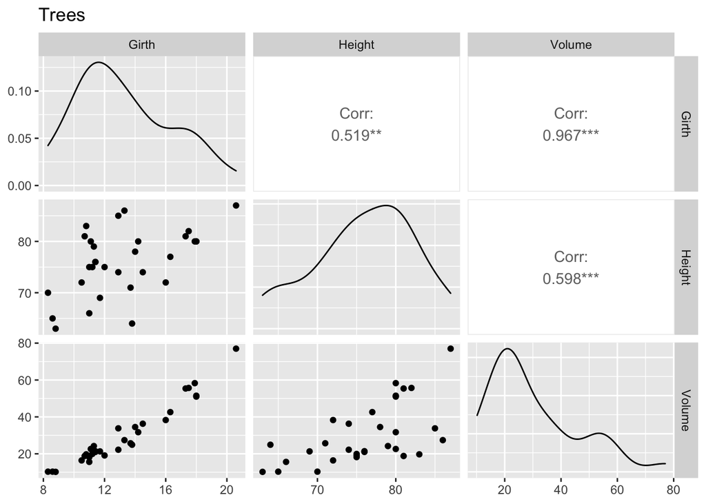

```r
ggpairs(chery_trees, columns = 1:3, title="Trees")
```

*El gráfico nos muestra en la diagonal la distribucion de la variable, a la derecha de esta la correlación de pearson y en la izquierda de la diagonal los scaterplots correspondiente a cada par de variables numericas*

Podemos observar que existe una relacion del tipo lineal o cuadratica entre el `volume` y el `girth,`acompañado a su vez de una correlación de 0.97 aproximadamente, lo que nos indica que hay una relacion positiva entre ambas variables, en otras palabras a medida que una de estas crece la otra también lo hace.

Lo dicho anteriormente se puede verificar realizando el siguiente gráfico que se muestra a continuación

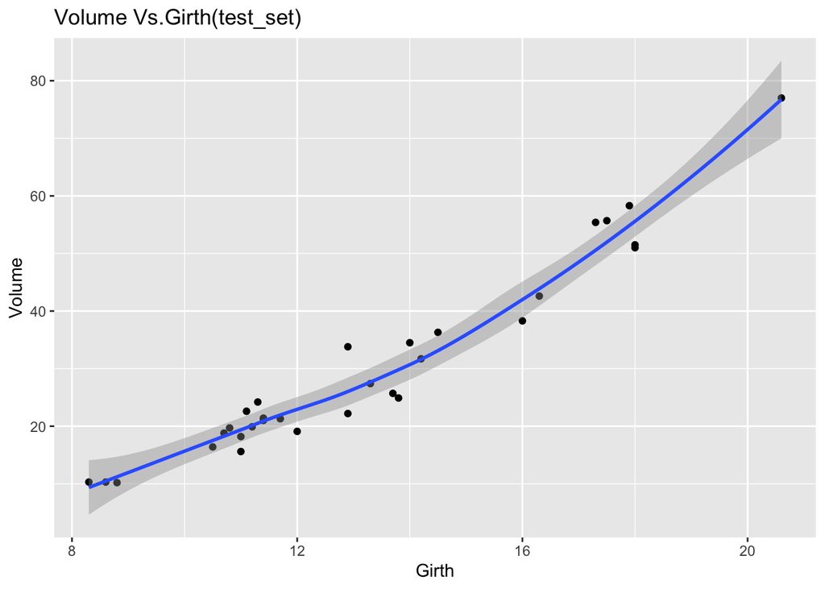

```r
ggplot(chery_trees, aes(Girth, Volume)) + geom_point()+geom_smooth() +
ggtitle("Volume Vs.Girth(test_set)") + xlab("Girth") + ylab("Volume")
```

No es perfectamente recto, pero podemos suponer linealidad ya que es casi lineal.

Aunque las otras dos correlaciones asociadas principalemente a la relación que existe entre `height` y las otras dos variables, es menor estas igual son positivas y de magnitudes interesantes, para esta también ocurre que la relación es positiva entre las variables.

**Histogramas**

Utilizamos histogramas para ver la distribución de las variables

```r
girth <- chery_trees %>%
  ggplot( aes(x=Girth)) +
    geom_histogram( binwidth=3, fill="#69b3a2", color="#e9ecef", alpha=0.9) +
    ggtitle("Distribucion de diámetro") +
    theme_ipsum() +
    theme(
      plot.title = element_text(size=8)
    )

volume <- chery_trees %>%
  ggplot( aes(x=Volume)) +
    geom_histogram( binwidth=3, fill="#db769d", color="#e9ecef", alpha=0.9) +
    ggtitle("Distribucion del volumen") +
    theme_ipsum() +
    theme(
      plot.title = element_text(size=8)
    )

height <- chery_trees %>%
  ggplot( aes(x=Height)) +
    geom_histogram( binwidth=3, fill="#9a76db", color="#e9ecef", alpha=0.9) +
    ggtitle("Distribucion de la altura") +
    theme_ipsum() +
    theme(
      plot.title = element_text(size=8)
    )
```

```r
ggarrange(girth, volume, height,
          nrow = 1,
          ncol = 2
          )
```

[output not shown]

[output cut: 70 more lines]

[output not shown]

```
## $`1`
```

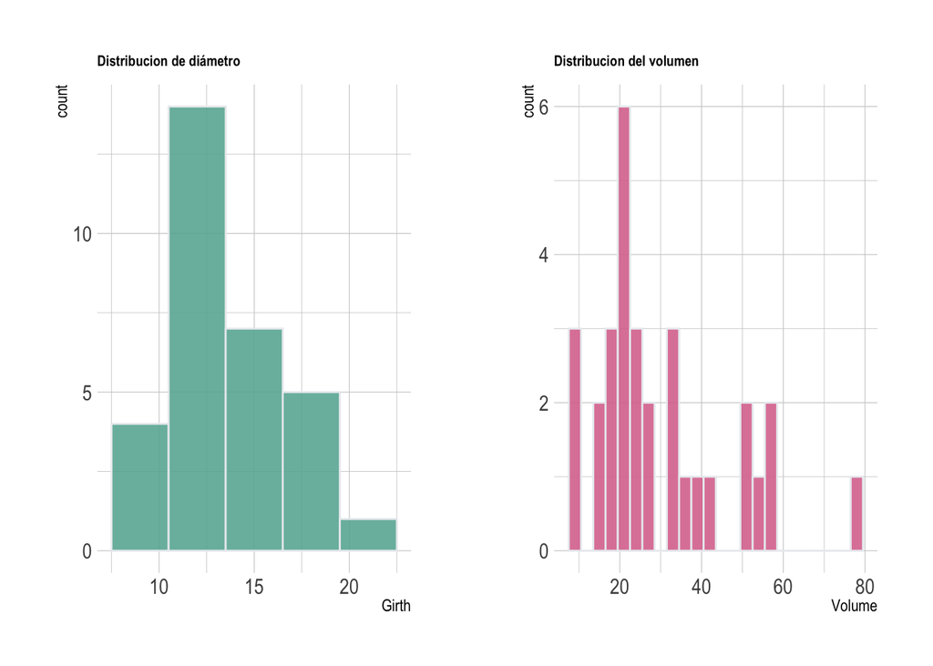

```
##
## $`2`
```

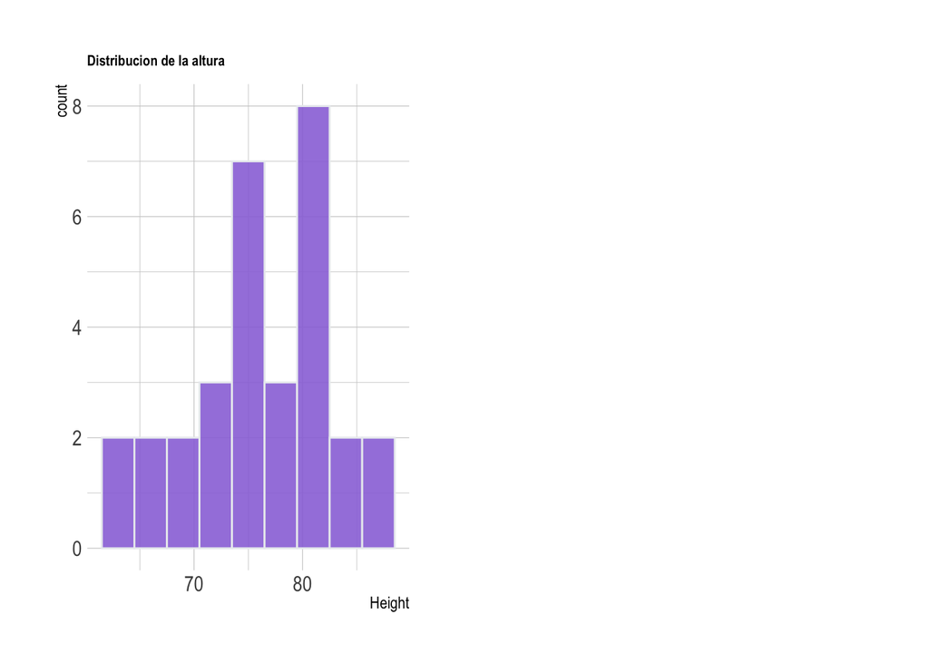

```
##
## attr(,"class")
## [1] "list"      "ggarrange"
```

**Boxplot**

```
## $`1`
```

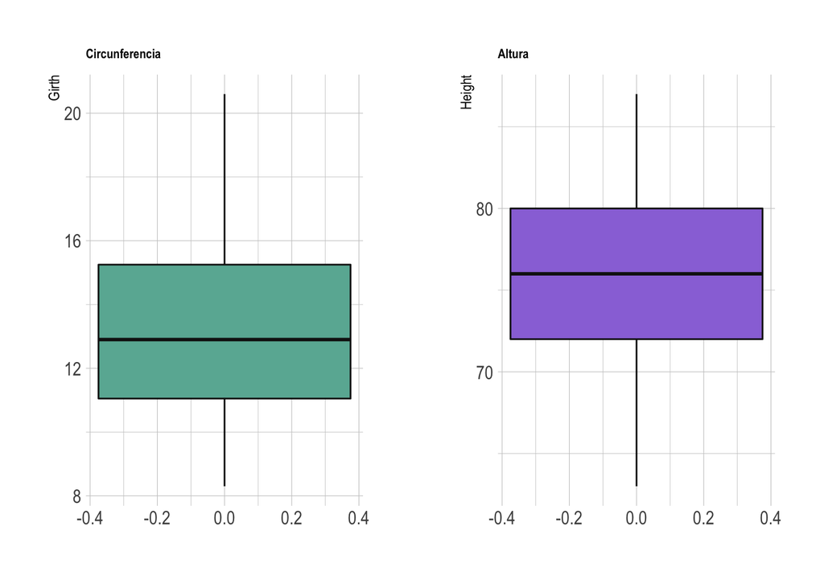

```
##
## $`2`
```

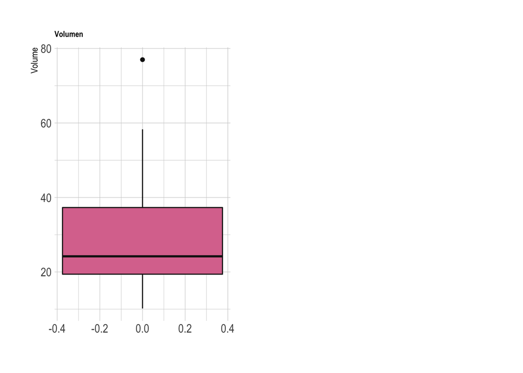

```
##
## attr(,"class")
## [1] "list"      "ggarrange"
```

```r
 bg <- chery_trees %>%
  ggplot(aes(y=Girth)) +
    geom_boxplot(binwidth=0.5,fill="#69b3a2", color="#141414") +
    theme_ipsum() +
    theme(
      legend.position="none",
      plot.title = element_text(size=8)
    ) +
    ggtitle("Circunferencia") +
    xlab("")
  bv <- chery_trees %>%
  ggplot(aes(y=Volume)) +
    geom_boxplot(binwidth=0.5,fill="#db769d", color="#141414") +
    theme_ipsum() +
    theme(
      legend.position="none",
      plot.title = element_text(size=8)
    ) +
    ggtitle("Volumen") +
    xlab("")
   bh <- chery_trees %>%
  ggplot(aes(y=Height)) +
    geom_boxplot(binwidth=0.5,fill="#9a76db", color="#141414") +
    theme_ipsum() +
    theme(
      legend.position="none",
      plot.title = element_text(size=8)
    ) +
    ggtitle("Altura") +
    xlab("")
 ggarrange( bg,bh,bv,
            nrow = 1,
            ncol = 2)
```

Las variables presentan una ditribución pareja, la varible volumen tiene datos atípicos.

#### Correlación

```r
# Matriz de correlación
round(cor(x = chery_trees[c(1,2,3)], method = "pearson"),2)
```

```
##        Girth Height Volume
## Girth   1.00   0.52   0.97
## Height  0.52   1.00   0.60
## Volume  0.97   0.60   1.00
```

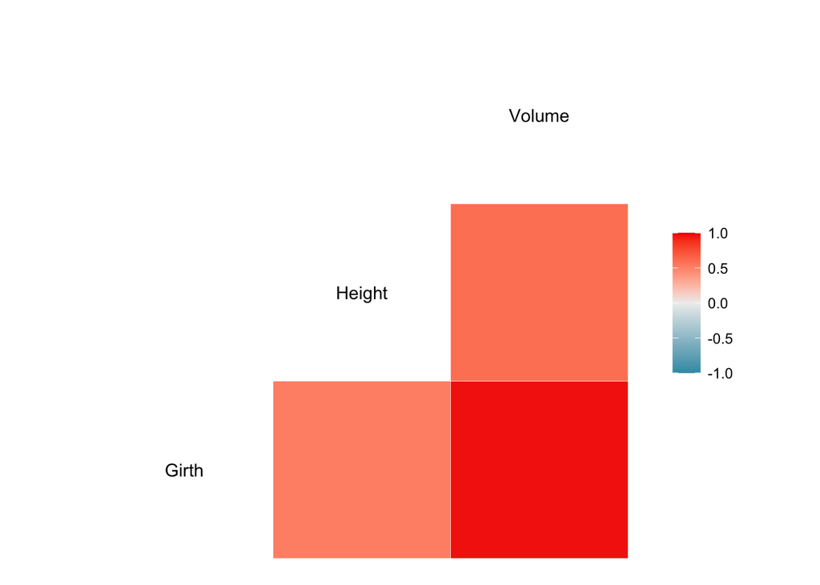

```r
# Linda forma de visualizar la matriz de correlacion
ggcorr(chery_trees, method = c("everything", "pearson"))
```

**Análisis:**

Con base en los resultados que hemos obtenido hasta el momento, se puede concluir que:

- En los gráficos de dispersión se puede observar que la variable Girth (diámetro) está más linealmente asociada con la variable respuesta Volumen.
- Hay una correlación alta entre la variable diámetro y volumen (**0.97**) y entre la variable volumen y altura la correlación es del **0.60** aproximadamente

### Modelo de regresión

Sabemos que podemos expresar elvolumen con la siguiente expresion matemática $volumen = area * altura$. Para este caso podríamos pensar como que el árbol puede representarce como el volumen de un cilindro. Considerando esto la fórmula que obtenemos es $ volumen = *radio^2*altura $. Expresado en función de los datos que contamos sería:
$$volume =
\pi*(\frac{girth}{2})^2*height$$
La ecuación expresada de esta manera no es lineal pero si le tomamos el logaritmo obtenemos:
$$log(volume) =
\log(\pi)+2*\log(\frac{girth}{2})+\log(height)$$
Reacomodando un poco los terminos
$$log(volume) = \log(\pi)
-\log(2)+2*\log(girth)+\log(height)$$
De la siguiente fórmula podemos deducir lo siguientes valores de los coefeicientes aproximados:

- $\beta_0 = \log(\pi) -\log(2) = 0.19$
- $\beta_1 = 2$ es el diámetroes la altura
- $\beta_2 = 1$ es la altura

De la teorización realizada y del análisis exploratorio se deduce que podemos proponer dos modelos uno que corresponda a una regresion lineal simple que explicaria el volumen en base al diametro y otro un modelo de regresión lineal múltiple, donde expresamos en forma de una fórmula matemática el volumen en función de la altura y del diámetro. Optamos por una regresion multiple que tendrá la siguiente forma:

$$Volume =
\beta_0+\beta_1height+\beta_2girth$$

#### Modelo de Regresión Multiple

Para ver cuál es la influencia que tienen la altura y el diámetro sobre el volumen estudiaremos un modelo de regresión múltiple

```r
# Modelo de regresión lineal
regressor_chery = lm (Volume ~ Girth+Height, data = chery_trees)

# Veamos los estadísticos del modelo
summary(regressor_chery )
```

```
##
## Call:
## lm(formula = Volume ~ Girth + Height, data = chery_trees)
##
## Residuals:
##     Min      1Q  Median      3Q     Max
## -6.4065 -2.6493 -0.2876  2.2003  8.4847
##
## Coefficients:
##             Estimate Std. Error t value Pr(>|t|)
## (Intercept) -57.9877     8.6382  -6.713 2.75e-07 ***
## Girth         4.7082     0.2643  17.816  < 2e-16 ***
## Height        0.3393     0.1302   2.607   0.0145 *
## ---
## Signif. codes:  0 '***' 0.001 '**' 0.01 '*' 0.05 '.' 0.1 ' ' 1
##
## Residual standard error: 3.882 on 28 degrees of freedom
## Multiple R-squared:  0.948,  Adjusted R-squared:  0.9442
## F-statistic:   255 on 2 and 28 DF,  p-value: < 2.2e-16
```

*Análisis:*

- Podemos ver que las dos variables son estadísticamente significativas
- Una vez construido el modelo de regresión lineal múltiple, también hemos establecido la relación entre el predictor $**X**$ y la respuesta $**Y**$ en forma de una fórmula matemática para el volumen en función de la altura y del diámetro.

*Datos*:

- $\beta_0 = -57.9877$
- $\beta_1 = 0.3393$ es la altura
- $\beta_2 = 4.7082$ es el diámetro
- $\hat{\sigma} = 3.882$
- $R^2 ajustado = 0.9442$

La recta ajustada del volumen que obtenemos es:
$$\hat{Volume} =
-57.9877+0.3393\hat{height}+4.7082\hat{girth}$$

Es importante destacar que cada una de las pendientes de un modelo de regresión lineal múltiple (coeficientes parciales de regresión de los predictores) se define del siguiente modo: Si el resto de variables se mantienen constantes, por cada unidad que aumenta el predictor en cuestión, la variable (Y) varía en promedio tantas unidades como indica la pendiente.

### Contraste de Hipotesis para nivel 0.01

Si queremos contrastar hipótesis sobre los coeficientes de la regresión:
$$H_0: \beta_i = b^*$$
$$H_1: \beta_i \ne b^*$$
basta con considerar los estadísticos correspondientes:
$$\hat{\beta_i} =
\frac{\hat{\beta_i}-\beta_i^0}{ee(\hat{\beta_i})}$$

**Para** $\beta_0$

*Datos* * $\alpha = 0.01$ * $ p-valor = 2.75e-07$

Como se cumple la condición $p-valor < \alpha$ se rechaza $H_0$

**Para** $\beta_1$

*Datos* * $\alpha = 0.01$ * $ p-valor = 0.0145$

Como se cumple la condición $p-valor > \alpha$ se dice que los datos no proporcionan suficientes evidencias encontra de la hipotesis nula y no se puede rechazar

**Para** $\beta_2$

*Datos* * $\alpha = 0.01$ * $ p-valor = 2e-16$

Como se cumple la condición $p-valor < \alpha$ se rechaza $H_0$

*Análisis* Comparado a los coeficientes que obtuvimos de pensar el modelo con matemática del colegio con los que obtuvimos del modelo podemos decir que pese a que $\beta_1$ y $\beta_2$ son positivos en magnitud son significa mayor para el caso del diámetro y menor para la altura. El `intercept` es muy diferente dado que en el modelo propuesto da negativo y con un valor de 57 y en el de matematica simple da positivo y cercano a 0.

### Calculo del Intervalo de Confianza para nivel 0.9

```r
confint(regressor_chery,level = 0.9)
```

```
##                    5 %        95 %
## (Intercept) -72.682412 -43.2929057
## Girth         4.258612   5.1577092
## Height        0.117847   0.5606554
```

Con el intervalo de confianza propuesto verificamos si los coeficientes propuestos en principio aunque sea caen en los valores obtenidos. Ninguno de los tres valores esta comprendido por el intervalo obtenido.

### Calculo de suma de cuadrados y media de cuadrados

Se ajusta un modelo con todos los predictores y el modelo nulo que contiene únicamente la medias. Modelo con todos los predictores `regressor_chery`

```r
anova <- aov(Volume ~ Girth+Height, data = chery_trees)
summary(anova)
```

```
##             Df Sum Sq Mean Sq F value Pr(>F)
## Girth        1   7582    7582 503.150 <2e-16 ***
## Height       1    102     102   6.794 0.0145 *
## Residuals   28    422      15
## ---
## Signif. codes:  0 '***' 0.001 '**' 0.01 '*' 0.05 '.' 0.1 ' ' 1
```

El contraste muestra claras evidencias ($p−value=2.2e^−16$) en contra de la hipótesis nula de que $\beta_0 =\beta_1=\beta_2=0$. El modelo en su conjunto es capaz de explicar la varianza en la variable *Volume* mejor de lo esperado por azar. Al menos uno de sus predictores contribuye de forma significativa a la predicción.

Los gradoas de libertad son 28, obtenemos este dato de la columna Df que muestra los *grados de libertad* de la variable independiente (el número de niveles de la variable menos 1) y los grados de libertad de los residuos (el número total de observaciones menos uno y menos el número de niveles de las variables independientes ). La columna *Sum Sq* muestra la suma de los cuadrados (también conocida como la variación total entre las medias del grupo y la media general) es de 7582 La columna *Mean Sq* es la media de la suma de los cuadrados, calculada dividiendo la suma de los cuadrados por los grados de libertad de cada parámetro. La columna *Pr(>F)* es el valor p de la estadística F. Esto muestra la probabilidad de que el valor F calculado a partir de la prueba se hubiera producido si la hipótesis nula de que no hay diferencia entre las medias de los grupos fuera cierta.En nuestro caso toma un vlor de 2.2e-16

### Test de Hipotesis simultáneo

¿Será que la inclusión simultánea de las variables $x_1$ y $x_2$ mejora el modelo para explicar la variable respuesta y? Use$\alpha = 0.05$ para concluir. Para el ejercicio nos interesa estudiar las siguientes dos hipótesis simultáneamente
$$H_0: \beta_1 = 0$$
$$H_1: \beta_1
\ne 0$$
$$H_0: \beta_2 = 0$$
$$H_1: \beta_2 \ne 0$$
Los dos conjuntos de hipótesis anteriores se pueden escribir matricialmente usando una matriz de constrate $C$ que multiplica al vector de parámetros $\beta$ y luego igualando es producto con el vector $\alpha = (0,0)^T$ que contiene lados derechos de las hipótesis anteriores.Teniendo definida la matriz $C$, el vector $\alpha$ la prueba simultánea de las hipótesis se puede hacer de la siguiente manera.

```r
C <- matrix(c(0, 1, 0,
              0, 0, 1), ncol=3, byrow=TRUE)
mult_test <- glht(model=regressor_chery, linfct=C, alternative='two.sided', rhs=c(0, 0))
summary(mult_test, test = adjusted(type="single-step"))
```

```
##
##   Simultaneous Tests for General Linear Hypotheses
##
## Fit: lm(formula = Volume ~ Girth + Height, data = chery_trees)
##
## Linear Hypotheses:
##        Estimate Std. Error t value Pr(>|t|)
## 1 == 0   4.7082     0.2643  17.816   <1e-10 ***
## 2 == 0   0.3393     0.1302   2.607   0.0268 *
## ---
## Signif. codes:  0 '***' 0.001 '**' 0.01 '*' 0.05 '.' 0.1 ' ' 1
## (Adjusted p values reported -- single-step method)
```

De la salida anterior se obtiene que los dos $p-valores$ “ajustados” son:
$$q_1=1e^{-10}$$
$$q_2=0.0268$$
Lo que significa que dado que ambos $p-valoeres < \alpha$ estamos en condiciones de rechazar:
$$H_0:
\beta_1 = 0$$
$$H_0: \beta_2 = 0$$
En otras palabras, las variables $x_1$ y $x_2$ aportan información para explicar la media de $Y$.

## Ejercicio 5

| Father | mother | midparentHeight | gender | childHeight |
| --- | --- | --- | --- | --- |
| Altura del padre | Altura del madre | altura promedio de la madre y el padre, calculada como (father +1.08*mother)/2. | sexo del hijo. | altura del hijo |
| cuantitativa | cuantitativa | cuantitativa | Cualitativa | Cuantitativa |

```r
high_galton <- read.table('AlturaGalton.txt', skip = 0, header = TRUE, sep =' ')
high_galton
```

```
##     father mother midparentHeight gender childHeight
## 1     78.5   67.0          75.430 female        69.2
## 2     78.5   67.0          75.430   male        73.2
## 3     75.5   66.5          73.660 female        65.5
## 4     75.5   66.5          73.660   male        72.5
## 5     75.0   64.0          72.060 female        68.0
## 6     75.0   64.0          72.060   male        71.0
## 7     75.0   64.0          72.060 female        63.0
## 8     75.0   64.0          72.060   male        68.5
## 9     75.0   58.5          69.090 female        62.5
## 10    75.0   58.5          69.090   male        72.0
## 11    74.0   68.0          73.720 female        69.5
## 12    74.0   68.0          73.720 female        70.5
## 13    74.0   68.0          73.720   male        73.0
## 14    74.0   66.5          72.910 female        68.0
```

[output cut: 341 more lines]

### Analisis exploratorio

#### Composición del dataset

```r
# Imprimo los primeros 6 resultados
first_six_results = head(high_galton)
first_six_results
```

```
##   father mother midparentHeight gender childHeight
## 1   78.5   67.0           75.43 female        69.2
## 2   78.5   67.0           75.43   male        73.2
## 3   75.5   66.5           73.66 female        65.5
## 4   75.5   66.5           73.66   male        72.5
## 5   75.0   64.0           72.06 female        68.0
## 6   75.0   64.0           72.06   male        71.0
```

Información general

```r
str(high_galton)
```

```
## 'data.frame':    355 obs. of  5 variables:
##  $ father         : num  78.5 78.5 75.5 75.5 75 75 75 75 75 75 ...
##  $ mother         : num  67 67 66.5 66.5 64 64 64 64 58.5 58.5 ...
##  $ midparentHeight: num  75.4 75.4 73.7 73.7 72.1 ...
##  $ gender         : chr  "female" "male" "female" "male" ...
##  $ childHeight    : num  69.2 73.2 65.5 72.5 68 71 63 68.5 62.5 72 ...
```

Contamos con 355 observaciones y 5 variables de las cuales `gender` es la única cualitativa

Obtenemos los estadisticos principales

```r
# Vemos los estadísticos principales
summary_galton = summary(high_galton)
summary_galton
```

```
##      father          mother      midparentHeight    gender
##  Min.   :62.00   Min.   :58.00   Min.   :64.40   Length:355
##  1st Qu.:68.00   1st Qu.:63.00   1st Qu.:68.02   Class :character
##  Median :69.20   Median :64.00   Median :69.18   Mode  :character
##  Mean   :69.26   Mean   :64.06   Mean   :69.22
##  3rd Qu.:71.00   3rd Qu.:65.75   3rd Qu.:70.35
##  Max.   :78.50   Max.   :70.50   Max.   :75.43
##   childHeight
##  Min.   :57.0
##  1st Qu.:64.0
##  Median :66.5
##  Mean   :66.7
##  3rd Qu.:69.6
##  Max.   :75.0
```

#### Análisis gráfico

**Correlacion entre variables, distribución y scaterplots**

Relación entre variables cuantitativas (excluimos) `gender`

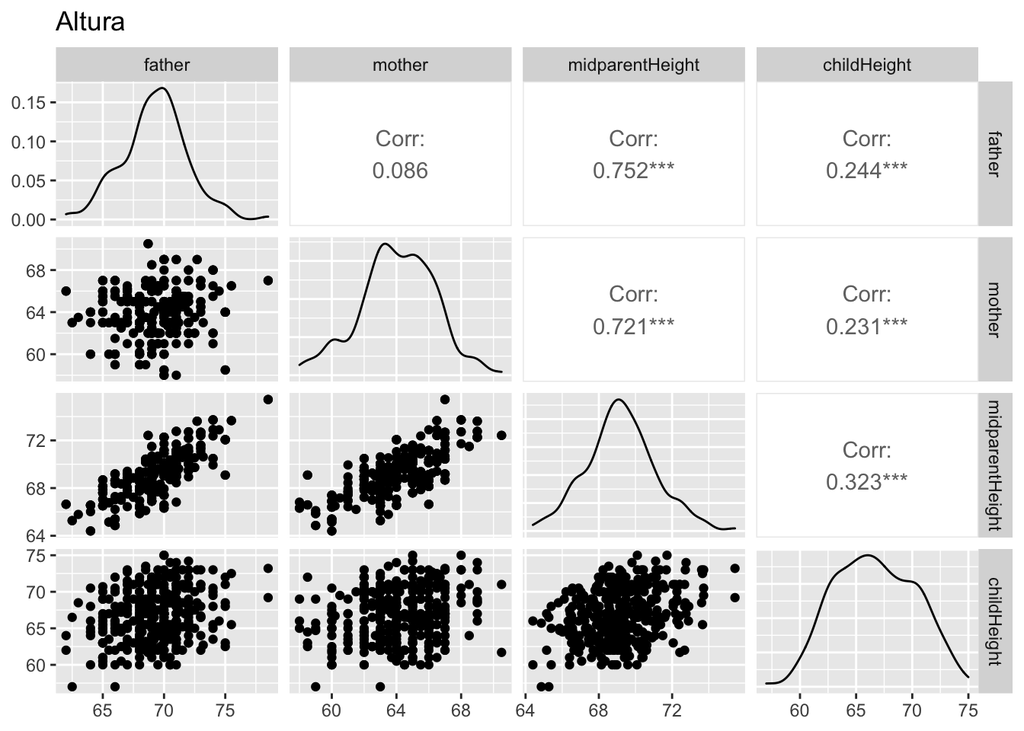

```r
ggpairs(high_galton, columns = c(1:3,5), title="Altura ")
```

Podemos observar que existe una relacion del tipo lineal o cuadratica entre `midparentHeight` y `father` y `mother`acompañado a su vez de una correlación deasociacion alta ambas por encima de 0.7 aproximadamente, lo que nos indica que hay una relacion positiva entre ambas variables, en otras palabras a medida que una de estas crece la otra también lo hace. Esto tiene sentido dado que ese campo se calcula utilizando ambos valores (`father` y `mother`)

Lo dicho anteriormente se puede verificar realizando el siguiente gráfico que se muestra a continuación

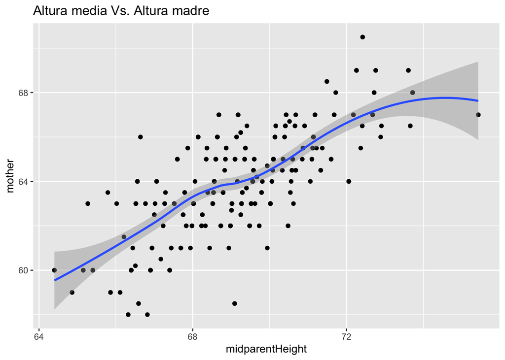

```r
ggplot(high_galton, aes(midparentHeight, mother)) + geom_point()+geom_smooth()+
ggtitle("Altura media Vs. Altura madre") + xlab("midparentHeight") + ylab("mother")
```

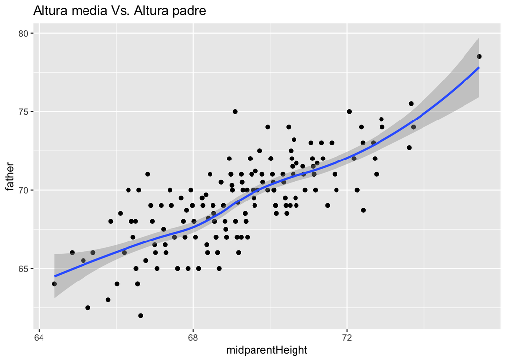

```r
ggplot(high_galton, aes(midparentHeight, father)) + geom_point()+geom_smooth()+
ggtitle("Altura media Vs. Altura padre") + xlab("midparentHeight") + ylab("father")
```

No es perfectamente recto, pero podemos suponer linealidad ya que es casi lineal.

Las otras correlaciones son positivas, podemos decir que aquellas que estan entre 0.2 y 0.3 tienen una asociacion mediana mientras que la que es menor a 0.1 es pequeña.

**Histogramas**

Utilizamos histogramas para ver la distribución de las variables

```
## $`1`
```

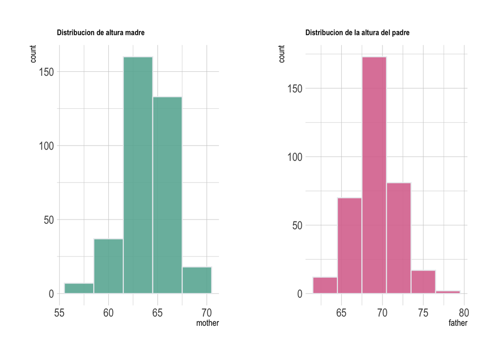

```
##
## $`2`
```

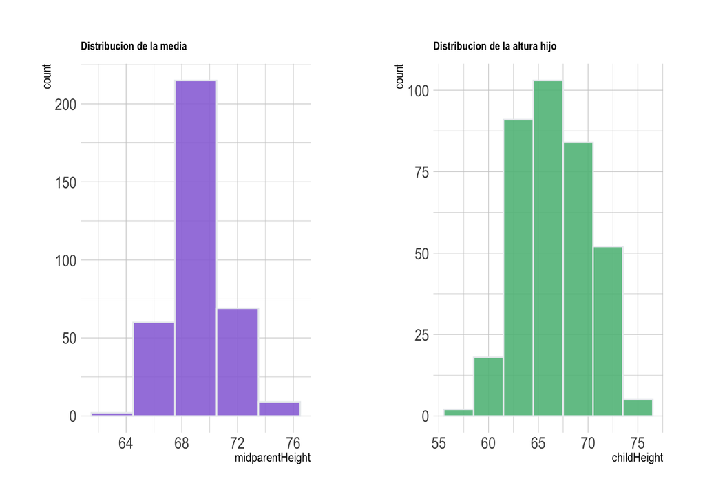

```
##
## attr(,"class")
## [1] "list"      "ggarrange"
```

```r
hm <- high_galton %>%
  ggplot( aes(x=mother)) +
    geom_histogram( binwidth=3, fill="#69b3a2", color="#e9ecef", alpha=0.9) +
    ggtitle("Distribucion de altura madre") +
    theme_ipsum() +
    theme(
      plot.title = element_text(size=8)
    )

hf <- high_galton %>%
  ggplot( aes(x=father)) +
    geom_histogram( binwidth=3, fill="#db769d", color="#e9ecef", alpha=0.9) +
    ggtitle("Distribucion de la altura del padre") +
    theme_ipsum() +
    theme(
      plot.title = element_text(size=8)
    )

hmp <- high_galton %>%
  ggplot( aes(x=midparentHeight)) +
    geom_histogram( binwidth=3, fill="#9a76db", color="#e9ecef", alpha=0.9) +
    ggtitle("Distribucion de la media") +
    theme_ipsum() +
    theme(
      plot.title = element_text(size=8)
    )


hc <- high_galton %>%
  ggplot( aes(x=childHeight)) +
    geom_histogram( binwidth=3, fill="#60bd88", color="#e9ecef", alpha=0.9) +
    ggtitle("Distribucion de la altura hijo") +
    theme_ipsum() +
    theme(
      plot.title = element_text(size=8)
    )

ggarrange(hm, hf, hmp,hc,
          nrow = 1,
          ncol = 2
          )
```

**Boxplot**

```
## $`1`
```

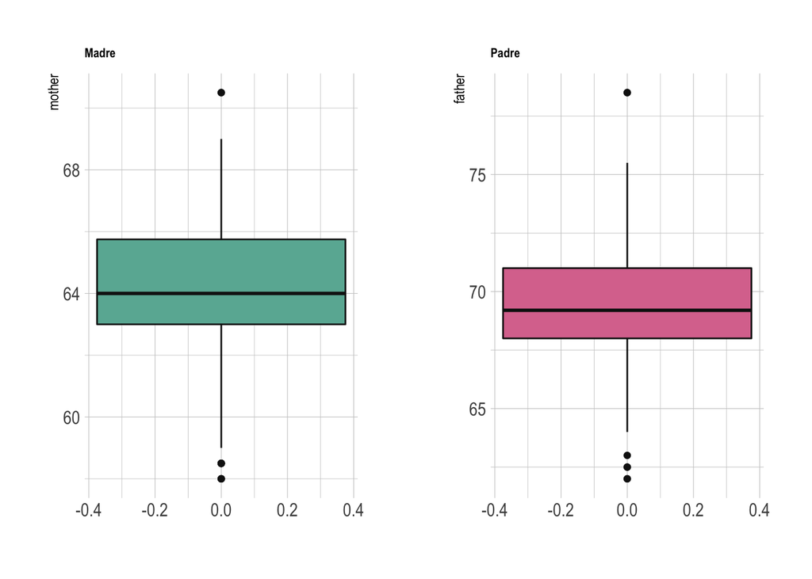

```
##
## $`2`
```

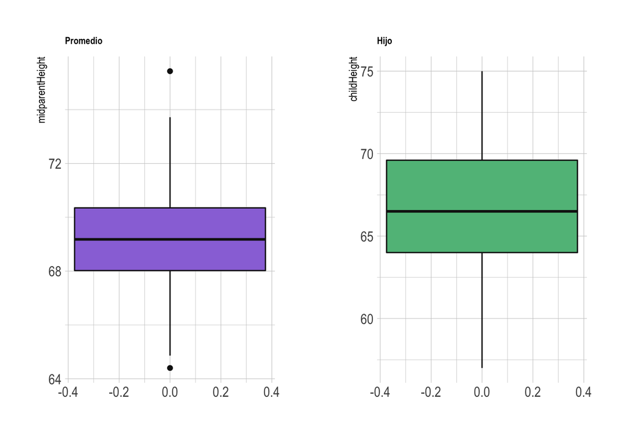

```
##
## attr(,"class")
## [1] "list"      "ggarrange"
```

```r
 bm <- high_galton %>%
  ggplot(aes(y=mother)) +
    geom_boxplot(binwidth=0.5,fill="#69b3a2", color="#141414") +
    theme_ipsum() +
    theme(
      legend.position="none",
      plot.title = element_text(size=8)
    ) +
    ggtitle("Madre") +
    xlab("")
  bf <- high_galton %>%
  ggplot(aes(y=father)) +
    geom_boxplot(binwidth=0.5,fill="#db769d", color="#141414") +
    theme_ipsum() +
    theme(
      legend.position="none",
      plot.title = element_text(size=8)
    ) +
    ggtitle("Padre") +
    xlab("")
   bmp <- high_galton %>%
  ggplot(aes(y=midparentHeight)) +
    geom_boxplot(binwidth=0.5,fill="#9a76db", color="#141414") +
    theme_ipsum() +
    theme(
      legend.position="none",
      plot.title = element_text(size=8)
    ) +
    ggtitle("Promedio") +
    xlab("")
   bc <- high_galton %>%
  ggplot(aes(y=childHeight)) +
    geom_boxplot(binwidth=0.5,fill="#60bd88", color="#141414") +
    theme_ipsum() +
    theme(
      legend.position="none",
      plot.title = element_text(size=8)
    ) +
    ggtitle("Hijo") +
    xlab("")
  ggarrange( bm,bf,bmp,bc,
            nrow = 1,
            ncol = 2)
```

Las variables presentan una ditribución simétrica, las varibles de la altura de la madre, padre y el promedio tiene datos atípicos.

#### Correlación

```r
# Matriz de correlación
round(cor(x = high_galton[c(1:3,5)], method = "pearson"),2)
```

```
##                 father mother midparentHeight childHeight
## father            1.00   0.09            0.75        0.24
## mother            0.09   1.00            0.72        0.23
## midparentHeight   0.75   0.72            1.00        0.32
## childHeight       0.24   0.23            0.32        1.00
```

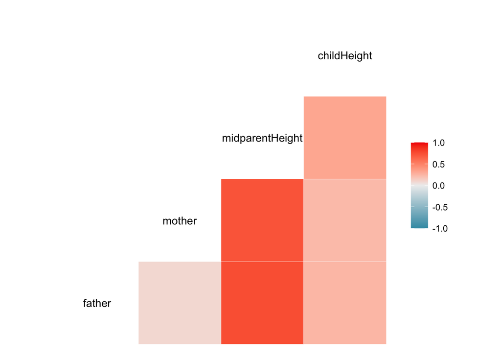

```r
# Linda forma de visualizar la matriz de correlacion
ggcorr(high_galton, method = c("everything", "pearson"))
```

**Análisis:**

### Modelo de regresión

Vamos a realizar un modelo de regresión múltiple para predecir la altura de los hijos en función de la altura de la madre, padre y la altura promedio de estos. Optamos por una regresion multiple que tendrá la siguiente forma:

$$Child_{height} =
\beta_0+\beta_1father+\beta_2mother+\beta_3midparent_{height}$$

**Posibles modelos** *Opción 1 regresión líneal simple:* $Child_{height} = \beta_0+\beta_1midparent_{height}$ *Opción 2 regresión líneal múltiple:*$Child_{height} = \beta_0+\beta_1father+\beta_2mother+\beta_3midparent_{height}$ #### Criterios de selección de modelos Al igual que ocurre en los modelos lineales simples, $R^2$ (coeficiente de determinación) es un cuantificador de la bondad de ajuste del modelo. Se define como el porcentaje de varianza de la variable $Y$ que se explica mediante el modelo respecto al total de variabilidad. Por lo tanto, permite cuantificar como de bueno es el modelo para predecir el valor de las observaciones.

En los modelos lineales múltiples, cuantos más predictores se incluyan en el modelo mayor es el valor de $R^2$, ya que, por poco que sea, cada predictor va a explicar una parte de la variabilidad observada en $Y$. Es por esto que $R^2$ no puede utilizarse para comparar modelos con distinto número de predictores.

$R^2_{ajustado}$ introduce una penalización al valor de $R^2$ por cada predictor que se introduce en el modelo. El valor de la penalización depende del número de predictores utilizados y del tamaño de la muestra, es decir, del número de grados de libertad. Cuanto mayor es el tamaño de la muestra, más predictores se pueden incorporar en el modelo. $R^2_{ajustado}$ permite encontrar el mejor modelo, aquel que consigue explicar mejor la variabilidad de Y con el menor número de predictores. Si bien es un método para evaluar la bondad de ajuste muy utilizado, hay otros.

Para conocer la variabilidad que explica cada uno de los predictores incorporadas en el modelo se recurre a un ANOVA, ya que es el método que se encarga de analizar la varianza.

Tal y como ocurre en los modelos lineales simples o en los estudios de correlación, por muy alta que sea la bondad de ajuste, si el test F no resulta significativo no se puede aceptar el modelo como válido puesto que no es capaz de explicar la varianza observada mejor de lo esperado por azar.

```r
#Modelo de regresion lineal simple

high_linear_regressor <- lm(childHeight~midparentHeight, data=high_galton)
summary(high_linear_regressor)
```

```
##
## Call:
## lm(formula = childHeight ~ midparentHeight, data = high_galton)
##
## Residuals:
##     Min      1Q  Median      3Q     Max
## -7.2977 -2.6357 -0.1856  2.7705  7.7658
##
## Coefficients:
##                 Estimate Std. Error t value Pr(>|t|)
## (Intercept)     24.61510    6.57035   3.746 0.000209 ***
## midparentHeight  0.60798    0.09488   6.408 4.73e-10 ***
## ---
## Signif. codes:  0 '***' 0.001 '**' 0.01 '*' 0.05 '.' 0.1 ' ' 1
##
## Residual standard error: 3.391 on 353 degrees of freedom
## Multiple R-squared:  0.1042, Adjusted R-squared:  0.1017
## F-statistic: 41.06 on 1 and 353 DF,  p-value: 4.73e-10
```

```r
#Modelo de regresion lineal simple

high_multiple_regressor <- lm(childHeight~father+mother+midparentHeight, data=high_galton)
summary(high_multiple_regressor)
```

```
##
## Call:
## lm(formula = childHeight ~ father + mother + midparentHeight,
##     data = high_galton)
##
## Residuals:
##     Min      1Q  Median      3Q     Max
## -7.2848 -2.6402 -0.1949  2.7697  7.7666
##
## Coefficients: (1 not defined because of singularities)
##                 Estimate Std. Error t value Pr(>|t|)
## (Intercept)     24.63048    6.58772   3.739 0.000216 ***
## father           0.30632    0.06860   4.466 1.08e-05 ***
## mother           0.32554    0.07788   4.180 3.68e-05 ***
## midparentHeight       NA         NA      NA       NA
## ---
## Signif. codes:  0 '***' 0.001 '**' 0.01 '*' 0.05 '.' 0.1 ' ' 1
##
## Residual standard error: 3.396 on 352 degrees of freedom
## Multiple R-squared:  0.1042, Adjusted R-squared:  0.09911
## F-statistic: 20.47 on 2 and 352 DF,  p-value: 3.885e-09
```

*Análisis* El **estadístico F** es una medida de cuánto mejora el modelo la predicción de la variable respuesta comparada con el nivel de imprecisión de los datos originales. Si el modelo es bueno, esperamos que la mejora en la predicción debida al modelo sea grande (de manera que MSReg sea grande) y que la diferencia entre el modelo y los datos observados sea pequeña (o sea, MSRes pequeña). Para el modelo de regresión múltiple el `F-statistic` es menor al obtenido por regresión lineal simple. Como el $R^2_{ajustado}$ disminuye al incorporar las variables $X_1$ y $X_2$ al modelo, esto es señal de que una vez que las variables $X_1, X_2, X_3$ se utilizan para predecir a $Y$ (altura hijo) , las variables altura madre y padre no contribuye a explicarla y no se debe incluir en el modelo

#### Análisis de la varianza

Se puede emplear un ANOVA para realizar un test de hipótesis y obtener un `p-value` que evalúe la hipótesis nula de que ambos modelos se ajustan a los datos igual de bien.

```r
anova(high_linear_regressor, high_multiple_regressor)
```

```
## Analysis of Variance Table
##
## Model 1: childHeight ~ midparentHeight
## Model 2: childHeight ~ father + mother + midparentHeight
##   Res.Df    RSS Df Sum of Sq      F Pr(>F)
## 1    353 4059.3
## 2    352 4059.3  1  0.025714 0.0022 0.9624
```

#### Grafico de dispersion childHeight vs midparentHeight

[figure not shown]

```r
ggplot(high_galton, aes(midparentHeight, childHeight, colour = gender)) + geom_point()+geom_smooth(aes(group = gender))+
ggtitle("Altura de hijos e hijas Vs.ALtura promedio") + xlab("Altura Hijo/a") + ylab("Altura media")
```